# Replication of Studies 1b-1c from Scarcity Frames Value by Shah et al. (2015, Psychological Science)

## jimorris@stanford.edu

### Introduction

Shah et al. examined whether scarcity affects cognition and accordingly lowers an individual’s susceptibility to context effects. In studies 1b-1d, the authors used a classic paradigm (Thaler’s “beer on the beach” problem) to investigate how scaricty affects the role of context cues in product valuation.

In this study, we attempted to replicate the results of Shah et al. by finding that the “beer on the beach” effect - where individuals provide a higher willingness to pay (WTP) for an identical beer when it is to be purchased from a resort bar compared to a grocery store - is moderated by income level. Specfically, we expect that unlike individuals with high income, individuals with low income will not show a significant difference in WTP between purchase contexts.

### Methods

#### Power Analysis

We calculated the power of studies 1b and 1c by recreating the analysis of Shah et al. Materials and data from the original study were made available online, here: https://osf.io/vyibm/files/. We specifically used the t-statistic of the interaction terms from the analysis of scenario frame and median split SES on WTP from studies 1b and 1c.

```r
rm(list=ls())

library(curl)

b = read.csv(curl("https://raw.githubusercontent.com/StanfordPsych254/jimorrisProject/master/original_materials_data/1b.csv"))

b$Split = factor(b$Split)
levels(b$Split)[1] = 'Low'
levels(b$Split)[2] = 'High'

b$Frame = factor(b$Resort)
levels(b$Frame)[1] = 'Store'
levels(b$Frame)[2] = 'Resort'

summary(lm(Beer~Split*Frame,data=b))
```

```
##
## Call:
## lm(formula = Beer ~ Split * Frame, data = b)
##
## Residuals:
##    Min     1Q Median     3Q    Max
## -6.577 -2.408 -0.444  0.786 42.423
##
## Coefficients:
##                       Estimate Std. Error t value Pr(>|t|)
## (Intercept)             5.3720     0.7037   7.634 2.66e-12 ***
## SplitHigh              -1.1577     1.0369  -1.116  0.26606
## FrameResort            -0.9275     1.0291  -0.901  0.36893
## SplitHigh:FrameResort   4.2901     1.4696   2.919  0.00406 **
## ---
## Signif. codes:  0 '***' 0.001 '**' 0.01 '*' 0.05 '.' 0.1 ' ' 1
##
## Residual standard error: 4.506 on 147 degrees of freedom
## Multiple R-squared:  0.08198,    Adjusted R-squared:  0.06325
## F-statistic: 4.376 on 3 and 147 DF,  p-value: 0.005544
```

With a sample of 151, the t-statistic of the interactive term is 2.919. This would suggest an effect size of .48.

```r
c = read.csv(curl("https://raw.githubusercontent.com/StanfordPsych254/jimorrisProject/master/original_materials_data/1c.csv"))

c$Split = factor(c$split)
levels(c$Split)[1] = 'Low'
levels(c$Split)[2] = 'High'

c$Frame = factor(c$resort)
levels(c$Frame)[1] = 'Store'
levels(c$Frame)[2] = 'Resort'

c$Beer = NA
c$pay[c$pay == '$3 '] = '3'
c$Beer = as.numeric(as.character(c$pay))

#Removed outliers in this study at less than 20; in d) left 20 in
c=c[c$Beer < 20,]

summary(lm(Beer~Split*Frame,data=c))
```

```
##
## Call:
## lm(formula = Beer ~ Split * Frame, data = c)
##
## Residuals:
##     Min      1Q  Median      3Q     Max
## -5.9092 -1.8065 -0.5596  1.1935  9.4404
##
## Coefficients:
##                       Estimate Std. Error t value Pr(>|t|)
## (Intercept)             5.5596     0.2323  23.931   <2e-16 ***
## SplitHigh              -0.1461     0.3132  -0.466   0.6411
## FrameResort             0.3495     0.3106   1.125   0.2610
## SplitHigh:FrameResort   1.0434     0.4441   2.350   0.0191 *
## ---
## Signif. codes:  0 '***' 0.001 '**' 0.01 '*' 0.05 '.' 0.1 ' ' 1
##
## Residual standard error: 2.649 on 574 degrees of freedom
##   (2 observations deleted due to missingness)
## Multiple R-squared:  0.03694,    Adjusted R-squared:  0.03191
## F-statistic:  7.34 on 3 and 574 DF,  p-value: 7.803e-05
```

With a sample of 604, the t-statistic of the interactive term is 2.350. This would suggest an effect size of .20.

```r
library(pwr)
pwr.t.test(d =.2, sig.level=.05, power = .8) #Power = .80
```

```
##
##      Two-sample t test power calculation
##
##               n = 393.4057
##               d = 0.2
##       sig.level = 0.05
##           power = 0.8
##     alternative = two.sided
##
## NOTE: n is number in *each* group
```

#### Materials

The materials from the original study were provided by the authors online.

In the below text, participants either saw the scenario with the parenthetical phrases or the bracketed phrases:

```
"You are lying on the beach on a hot day. All you have to drink is ice water. For the last hour you have been thinking about how much you would enjoy a nice cold bottle of your favorite brand of beer. A companion gets up to go make a phone call and offers to bring back a beer from the only nearby place where beer is sold (a fancy resort hotel) [a small, run-down grocery store]. He says that the beer might be expensive and so asks how much you are willing to pay for the beer. He says that he will buy the beer if it costs as much or less than the price you state. But if it costs more than the price you state he will not buy it. You trust your friend, and there is no possibility of bargaining with the (bartender) [store owner].

What price do you tell him?"
```

The income question was as follows:

```
"What is your total household income, including all earners in your household?

Less than $10,000
$10,000-$19,999
$20,000-$29,999
$30,000-$39,999
$40,000-$49,999
$50,000-$59,999
$60,000-$69,999
$70,000-$79,999
$80,000-$89,999
$90,000-$99,999
$100,000-$149,000
More than $150,000"
```

Finally, we also asked for the number of members in each household:

```
"Including you, how many people live in your household? (open ended)"
```

#### Procedure

The procedure was followed exactly as stated in the original study:

```
"Participants read the beer-on-the-beach scenario and indicated their WTP for the beer."
```

The mockup of the experiment can be viewed here (open in new tab): https://web.stanford.edu/~jimorris/Shah_2015_Rep/shahrep.html.

#### Analysis Plan

As with the original study, we removed outliers of the WTP measure that is more than 3 standard deviations from the mean and converted the income and household numbers variables to a single measure of SES. Following the analysis from the original study, this SES value was calculated by taking the midpoint of the participant’s income bin (or $150,000 for the highest bin) and then dividing that value by the square root of the participant’s household size.

Next, we ran two interaction analyses of scenario frame and SES.

In the first analyses we used a median split on SES. For this analysis, we used three different median split criterias: a) the median split of the original Study 1b (where median SES = 31819); b) the median split of the original Study 1c (where median SES = 25980); and c) the median split of the replication sample. An interaction of scenario and frame and SES (median split) was performed for each median split criteria.

In the second analyses we treated SES as a continuous variable. An additional interaction of scenario frame and SES (continuous) was performed.

#### Differences from Original Study

In the original study, the authors used 1b) mTurk, N = 151; 1c) mTurk, N = 604. The current study had a sample size of 413 and also used mTurk.

### (Post Data Collection) Methods Addendum

#### Actual Sample

The sample size was 413 (37% Female), with a median age of 31. 82% of participants identified themesleves as being caucasian.

#### Differences from pre-data collection methods plan

There were some slight changes from the pre-data collection plan. As stated above, we excluded a participant due to an error and one participant was removed for entering a household size of 0.

### Results

#### Data preparation

```r
library(tidyr)
library(dplyr)
library(ggplot2)
library(rjson)
library(psych)
library(knitr)
```

##### Import Data

```r
path = "/Users/Josh/Dropbox/Stanford PhD/Classes/Year 2/Winter 2016/Stats 254/Git/jimorrisProject/Projects/mturk/"
files = dir(paste0(path,"production-results/"),
             pattern = "*.json")
d.raw = data.frame()

for (f in files) {
  jf = paste0(path, "production-results/", f)
  jd = fromJSON(paste(readLines(jf), collapse=""))
  id = data.frame(workerid = jd$WorkerId,
                  wtp_g = jd$answers$data$wtp_g,
                  wtp_b = jd$answers$data$wtp_b,
                  income = jd$answers$data$income,
                  hh_num = jd$answers$data$hh,
                  beer_like = jd$answers$data$beer,
                  age = jd$answers$data$age,
                  gender = jd$answers$data$gen,
                  english = jd$answers$data$engl,
                  race = jd$answers$data$race_ethn,
                  comments = jd$answers$data$comments)
  d.raw = bind_rows(d.raw, id)
}
```

##### Cleaning Data

```r
d.raw$cond[d.raw$wtp_g == '$'] = 'Resort'
d.raw$cond[d.raw$wtp_b == '$'] = 'Store'
d.raw$Frame = factor(d.raw$cond, levels=c('Store','Resort'))

d.raw$wtp[d.raw$wtp_g == '$'] = d.raw$wtp_b[d.raw$wtp_g == '$']
d.raw$wtp[d.raw$wtp_b == '$'] = d.raw$wtp_g[d.raw$wtp_b == '$']
d.raw$wtp = as.numeric(gsub('\\$','',d.raw$wtp))

d.raw$income_num[d.raw$income == 1] = 5000
d.raw$income_num[d.raw$income == 2] = 15000
d.raw$income_num[d.raw$income == 3] = 25000
d.raw$income_num[d.raw$income == 4] = 35000
d.raw$income_num[d.raw$income == 5] = 45000
d.raw$income_num[d.raw$income == 6] = 55000
d.raw$income_num[d.raw$income == 7] = 65000
d.raw$income_num[d.raw$income == 8] = 75000
d.raw$income_num[d.raw$income == 9] = 85000
d.raw$income_num[d.raw$income == 10] = 95000
d.raw$income_num[d.raw$income == 11] = 125000
d.raw$income_num[d.raw$income == 12] = 150000

d.raw$hh_num = as.numeric(d.raw$hh_num)

d.raw$SES = d.raw$income_num / sqrt(d.raw$hh_num)

d.raw$beer_like = as.numeric(d.raw$beer_like)

d.raw$age = as.numeric(d.raw$age)

d.raw$gender = factor(d.raw$gender)
levels(d.raw$gender) = c("Female","Male","Other")

d.raw$english = factor(d.raw$english)

d.raw$race = factor(d.raw$race)
```

```r
table(d.raw$race)
```

```
##
##    amInd    asian    black hispanic   natHaw    other    white
##        4       40       21       25        3        5      338
```

```r
#Remove Duplicates from race
d = d.raw %>%
  select(workerid,Frame,wtp,SES,income_num,hh_num,beer_like,gender,age,english,race) %>%
  distinct(workerid)
```

```r
summary(d$age)
```

```
##    Min. 1st Qu.  Median    Mean 3rd Qu.    Max.
##   18.00   26.00   31.00   32.58   37.00   61.00
```

```r
table(d$gender)
```

```
##
## Female   Male  Other
##    154    258      1
```

##### Median Splits

We are running the median split analysis with three different median values - a) from Study 1b, b) from Study 1c, and c) from this sample. We are using the orignal median splits in order to analyze a more pure replication of Studies 1b and 1c. However, given that our sample for the replication may differ, we could have too few data points on one side or the other - so we will also use the sample median as well.

```r
#Median in Study 1b: 31819.80515
#Median in Study 2c: 25980.76211
ses_med_1 = 31819.80515
ses_med_2 = 25980.76211
ses_med_3 = median(d$SES)

d$SES_cat_1[d$SES < ses_med_1] = 'Low'
d$SES_cat_1[d$SES >= ses_med_1] = 'High'
d$SES_cat_1 = factor(d$SES_cat_1, levels = c('Low','High'))

d$SES_cat_2[d$SES < ses_med_2] = 'Low'
d$SES_cat_2[d$SES >= ses_med_2] = 'High'
d$SES_cat_2 = factor(d$SES_cat_2, levels = c('Low','High'))

d$SES_cat_3[d$SES < ses_med_3] = 'Low'
d$SES_cat_3[d$SES >= ses_med_3] = 'High'
d$SES_cat_3 = factor(d$SES_cat_3, levels = c('Low','High'))
```

##### Excluding Data

```r
#Exclude Data who saw both conditions in error - not Pre-registered
d = d[d$workerid != 'A1V9EDXHNQGAFV',]

#Remove Outliers (3 SD above and below mean)
wtp_hi = mean(d$wtp) + sd(d$wtp)*3
wtp_lo = mean(d$wtp) - sd(d$wtp)*3

#10 outliers were removed
d.out = d[d$wtp > wtp_lo & d$wtp < wtp_hi,]

#Exclude participant who are under 21 and don't have english as a native language
#Also those who select 0 for household - not Pre-Registered
d.final = d.out[d.out$age >= 21 & d.out$english == 'Yes' & d.out$hh_num != 0,]
```

### Confirmatory Analysis

#### Basic Visualization

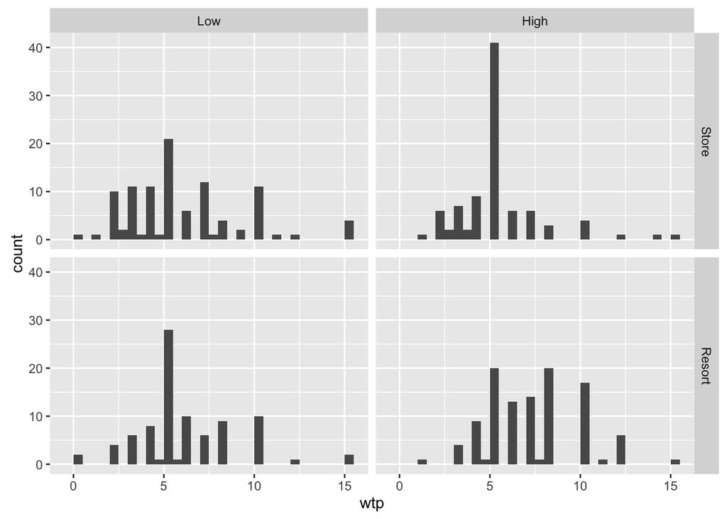

#### Original Study 1c Plot

This plot displays the results of Study 1c from Shah et al. (2015):

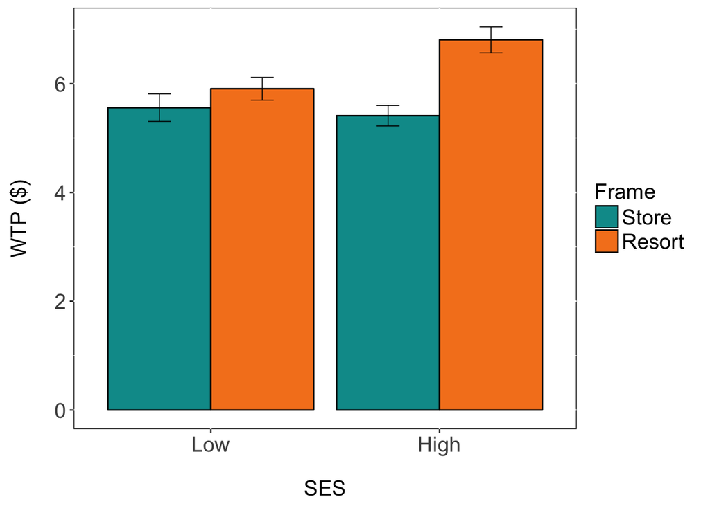

#### Replication Plot (using present sample median split)

This plot displays the results of our replication (using the present sample median split of SES):

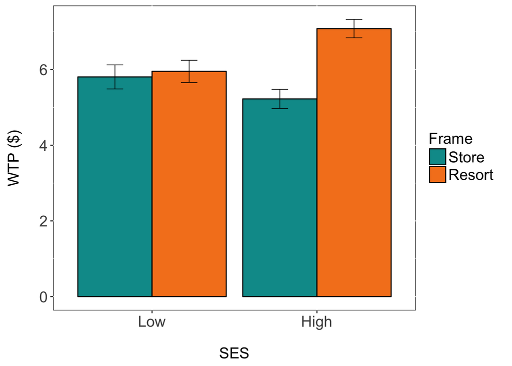

### Key Replication Test

For our key test of replication, we are analyzing whether the interaction of Frame (Resort vs. Grocery Store) and SES (using a median split of the new sample) on WTP for Beer is significant.

```r
reg_3_H = lm(wtp ~ Frame * SES_cat_3, data = d.final); summary(reg_3_H)
```

```
##
## Call:
## lm(formula = wtp ~ Frame * SES_cat_3, data = d.final)
##
## Residuals:
##     Min      1Q  Median      3Q     Max
## -6.0833 -1.8807 -0.2256  1.1931  9.7744
##
## Coefficients:
##                           Estimate Std. Error t value Pr(>|t|)
## (Intercept)                 5.8069     0.2721  21.343  < 2e-16 ***
## FrameResort                 0.1476     0.3987   0.370  0.71143
## SES_cat_3High              -0.5814     0.3964  -1.467  0.14325
## FrameResort:SES_cat_3High   1.7102     0.5579   3.065  0.00233 **
## ---
## Signif. codes:  0 '***' 0.001 '**' 0.01 '*' 0.05 '.' 0.1 ' ' 1
##
## Residual standard error: 2.734 on 383 degrees of freedom
## Multiple R-squared:  0.06013,    Adjusted R-squared:  0.05277
## F-statistic: 8.168 on 3 and 383 DF,  p-value: 2.772e-05
```

```r
kable(summary(reg_3_H)$coef)
```

|  | Estimate | Std. Error | t value | Pr(>\|t\|) |
| --- | --- | --- | --- | --- |
| (Intercept) | 5.8069307 | 0.2720780 | 21.3428901 | 0.0000000 |
| FrameResort | 0.1476148 | 0.3987337 | 0.3702089 | 0.7114315 |
| SES_cat_3High | -0.5813751 | 0.3963591 | -1.4667889 | 0.1432541 |
| FrameResort:SES_cat_3High | 1.7101630 | 0.5579347 | 3.0651670 | 0.0023297 |

### Other Planned Replication Analyses

We also plan to run a number of other related regressions using median splits for SES from the authors’ original samples and with SES as a continuous variable.

```r
#Interaction with different medians - when SES is high

#Study 1b Median
reg_1_H = lm(wtp ~ Frame * SES_cat_1, data = d.final); kable(summary(reg_1_H)$coef)
```

|  | Estimate | Std. Error | t value | Pr(>\|t\|) |
| --- | --- | --- | --- | --- |
| (Intercept) | 5.9111111 | 0.2874812 | 20.5617345 | 0.0000000 |
| FrameResort | -0.0844444 | 0.4264035 | -0.1980388 | 0.8431197 |
| SES_cat_1High | -0.7150715 | 0.3953351 | -1.8087731 | 0.0712703 |
| FrameResort:SES_cat_1High | 1.9297272 | 0.5629708 | 3.4277571 | 0.0006746 |

```r
#Study 1c Median
reg_2_H = lm(wtp ~ Frame * SES_cat_2, data = d.final); kable(summary(reg_2_H)$coef)
```

|  | Estimate | Std. Error | t value | Pr(>\|t\|) |
| --- | --- | --- | --- | --- |
| (Intercept) | 5.7837838 | 0.3175931 | 18.2113033 | 0.0000000 |
| FrameResort | -0.0962838 | 0.4663592 | -0.2064584 | 0.8365426 |
| SES_cat_2High | -0.4094248 | 0.4057839 | -1.0089726 | 0.3136248 |
| FrameResort:SES_cat_2High | 1.7295006 | 0.5812330 | 2.9755717 | 0.0031099 |

```r
#Change contrasts to see simple effects of Frame when SES is low
contrasts(d.final$SES_cat_1)=cbind(Low=c(1,0))
contrasts(d.final$SES_cat_2)=cbind(Low=c(1,0))
contrasts(d.final$SES_cat_3)=cbind(Low=c(1,0))

#Interaction with different medians - when SES is low

#Study 1b Median
reg_1_L = lm(wtp ~ Frame * SES_cat_1, data = d.final); kable(summary(reg_1_L)$coef)
```

|  | Estimate | Std. Error | t value | Pr(>\|t\|) |
| --- | --- | --- | --- | --- |
| (Intercept) | 5.1960396 | 0.2713751 | 19.147078 | 0.0000000 |
| FrameResort | 1.8452827 | 0.3675816 | 5.020063 | 0.0000008 |
| SES_cat_1Low | 0.7150715 | 0.3953351 | 1.808773 | 0.0712703 |
| FrameResort:SES_cat_1Low | -1.9297272 | 0.5629708 | -3.427757 | 0.0006746 |

```r
#Study 1c Median
reg_2_L = lm(wtp ~ Frame * SES_cat_2, data = d.final); kable(summary(reg_2_L)$coef)
```

|  | Estimate | Std. Error | t value | Pr(>\|t\|) |
| --- | --- | --- | --- | --- |
| (Intercept) | 5.3743590 | 0.2525771 | 21.278094 | 0.0000000 |
| FrameResort | 1.6332168 | 0.3469019 | 4.708008 | 0.0000035 |
| SES_cat_2Low | 0.4094248 | 0.4057839 | 1.008973 | 0.3136248 |
| FrameResort:SES_cat_2Low | -1.7295006 | 0.5812330 | -2.975572 | 0.0031099 |

```r
#Current Sample Median
reg_3_L = lm(wtp ~ Frame * SES_cat_3, data = d.final); kable(summary(reg_3_L)$coef)
```

|  | Estimate | Std. Error | t value | Pr(>\|t\|) |
| --- | --- | --- | --- | --- |
| (Intercept) | 5.2255556 | 0.2882258 | 18.130076 | 0.0000000 |
| FrameResort | 1.8577778 | 0.3902596 | 4.760364 | 0.0000027 |
| SES_cat_3Low | 0.5813751 | 0.3963591 | 1.466789 | 0.1432541 |
| FrameResort:SES_cat_3Low | -1.7101630 | 0.5579347 | -3.065167 | 0.0023297 |

```r
#Interaction with continuous SES
reg_c = lm(wtp ~ Frame * scale(SES), data = d.final); kable(summary(reg_c)$coef)
```

|  | Estimate | Std. Error | t value | Pr(>\|t\|) |
| --- | --- | --- | --- | --- |
| (Intercept) | 5.4910837 | 0.1980354 | 27.727794 | 0.0000000 |
| FrameResort | 1.0010018 | 0.2780174 | 3.600501 | 0.0003594 |
| scale(SES) | -0.3370473 | 0.2084734 | -1.616740 | 0.1067577 |
| FrameResort:scale(SES) | 1.0341032 | 0.2799852 | 3.693421 | 0.0002534 |

### Supplemental Analyses

We also chose to add a supplemental analysis that controls for how much participants like beer. If liking of beer is corrlated with SES, controlling for liking of beer may explain some of the differences in the focal effect.

Below, we run a) the 3-way interaction of Frame, SES, and liking of beer on WTP; b) the interaction of Frame and SES on WTP, when controlling for liking of beer; and c) the interaction of Frame and SES on WTP, when excluding participants who picked the lowest score for liking of beer (1 - Not At All).

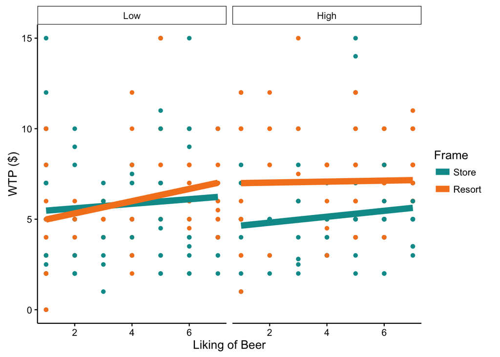

```r
#3-way Interaction with liking of beer
reg_c_b.1 = lm(wtp ~ Frame * SES * I(scale(beer_like)-1), data = d.final); kable(summary(reg_c_b.1)$coef)
```

|  | Estimate | Std. Error | t value | Pr(>\|t\|) |
| --- | --- | --- | --- | --- |
| (Intercept) | 6.2761192 | 0.5845267 | 10.7370965 | 0.0000000 |
| FrameResort | 0.0562163 | 0.8373049 | 0.0671396 | 0.9465060 |
| SES | -0.0000135 | 0.0000133 | -1.0126583 | 0.3118695 |
| I(scale(beer_like) - 1) | 0.1207025 | 0.3764382 | 0.3206436 | 0.7486572 |
| FrameResort:SES | 0.0000276 | 0.0000181 | 1.5246624 | 0.1281773 |
| FrameResort:I(scale(beer_like) - 1) | 0.7776685 | 0.5403185 | 1.4392779 | 0.1508972 |
| SES:I(scale(beer_like) - 1) | 0.0000048 | 0.0000093 | 0.5188982 | 0.6041346 |
| FrameResort:SES:I(scale(beer_like) - 1) | -0.0000208 | 0.0000127 | -1.6381114 | 0.1022284 |

```r
#Interaction controlling for liking of beer
reg_c_b.2 = lm(wtp ~ Frame * SES + beer_like, data = d.final); kable(summary(reg_c_b.2)$coef)
```

|  | Estimate | Std. Error | t value | Pr(>\|t\|) |
| --- | --- | --- | --- | --- |
| (Intercept) | 5.6096637 | 0.4517355 | 12.418027 | 0.0000000 |
| FrameResort | -0.7927076 | 0.5547568 | -1.428928 | 0.1538421 |
| SES | -0.0000182 | 0.0000097 | -1.876727 | 0.0613176 |
| beer_like | 0.1371764 | 0.0678405 | 2.022044 | 0.0438684 |
| FrameResort:SES | 0.0000480 | 0.0000129 | 3.720015 | 0.0002291 |

```r
#Interaction excluding individuals who do not like beer
d.beer = d.final[d.final$beer_like != 1,]
reg_c_b.3 = lm(wtp ~ Frame * I(scale(SES)), data = d.beer); kable(summary(reg_c_b.3)$coef)
```

|  | Estimate | Std. Error | t value | Pr(>\|t\|) |
| --- | --- | --- | --- | --- |
| (Intercept) | 5.4926699 | 0.2099538 | 26.1613241 | 0.0000000 |
| FrameResort | 1.1738607 | 0.2965720 | 3.9580971 | 0.0000936 |
| I(scale(SES)) | -0.1993459 | 0.2232625 | -0.8928765 | 0.3726114 |
| FrameResort:I(scale(SES)) | 0.7666958 | 0.2989919 | 2.5642692 | 0.0108072 |

### Discussion

#### Summary of Replication Attempt

The primary result of the replication analysis was the interaction of Frame and the median split of SES on WTP. Indeed, the result replicated. The interaction was significant, *b* = 1.71, *t* = 3.07, *p* = .002. Additionally, the simple effect of Frame on WTP was significant among participants high in SES (*b* = 1.86, *t* = 4.76, *p* < .001), however, it was not significant among participants low in SES (*b* = .15, *t* = 0.37, *p* = .711).

#### Commentary

In addition to replicating on the pre-registered key replication statistic, a number of robustness tests also replicated. This includes: a) the same interactions using median splits derived from the medians of the authors’ original tests; and b) the same interaction when treating SES as a continuous measure.

Furthermore, we collected data regarding participant’s liking of beer and the key interaction was also significant when controlling for liking of beer and when exluding participants who rated liking of beer at the lowest value (“1 - Not At All”). One interesting potential follow-up is that a three-way interaction of Frame, SES, and beer liking was marginally significant (*p* = .102). Since a three-way interaction may have been under-powered in this sample, future research could seek to explore this potential boundary.